# A Brief Introduction to ERGMs

SSC 2026 ERGM Workshop · Module 1

## How this workshop came about

- This is a research problem on fitting an exponential random graph model (ERGM) to a directed **32,000-node** syringe-sharing network (HepCEP).
- We first modeled this using the `ergm` v3.x, part of the `statnet` suite in R.<sup>1</sup>
- As the synthetic population evolved to incorporate more realistic demographic structures, we needed to refit the ERGM.
- But, the ERGM no longer fit “out of the box”.
[^1]: Boodram et al. (2022), *PLoS ONE* 17(1): e0248850. doi:10.1371/journal.pone.0248850

## How this workshop came about (cont’d)

- Refitting started with a long conversation with the **statnet_help community** in 2024.
- Following this, we worked through a chain of modeling steps and tuning of fitting parameters, often starting with some educated guesswork.
- Once we got the ERGM fitting sequence to work, we wanted to share the decisions we worked through as a pipeline with the ABM community interested in incorporating empirical networks.

## Why we Developed this Workshop

- The **ABM community** increasingly wants networked populations — but the practical ERGM-fitting know-how is **scattered and largely undocumented**.
- This workshop packages that pipeline as a **reproducible, hands-on toolkit**: aggregate summaries → convergent ERGM → simulated networks → ABM inputs.
- The emphasis is **practical judgment**, including diagnosis, tuning, and checking fits in practice.
- The workshop example includes a 1000-node network extracted from our “research problem,” to enable us to experiment with the steps in real time.
- The full pipeline will be made available in a GitHub repository once the paper is submitted for review.

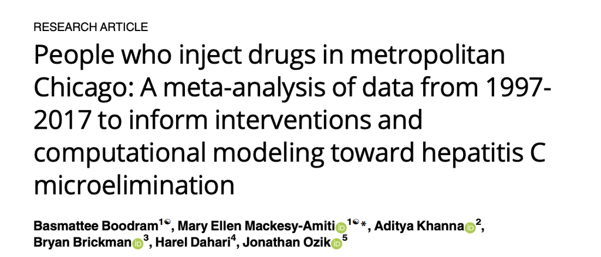

## Module 1: Introducting the Core Concepts

- Core ideas in 30 minutes, on a familiar example: **teen friendships**
- Builds to the workshop’s key concepts end to end.
- **No ERGM experience needed**

## Based on the statnet tutorial

[figure not shown]

Reused under CC‑BY

## The question

- How do adolescents form friendships?
- What processes generate the network structures we see?

**Micro-level processes → macro-level structure**

- The same **micro → macro** process that **ABMs** are useful for.
- That is, localized rules produce emergent structure.
- Here, this **micro → macro** pipeline is followed for modeling network structure.

## Where We Are Going

1. **Describe** the network: what does the structure look like?
2. **Summarize** it numerically: these network **summary statistics** become our **targets** for evaluating the quality of the fitted ERGM (akin to calibration in ABMs).
3. **Model** it: null (random mixing) vs. **assortative** mixing, incorporating a known mechanism (“homophily”) of friendship formation.
4. **Simulate**: do networks from the model reproduce the empirical structure — i.e., our **target statistics**?

## The data

```r
library(statnet)
data("faux.magnolia.high")
fmh <- faux.magnolia.high

c(students = network.size(fmh),
  ties     = network.edgecount(fmh))
```

```
students     ties
    1461      974
```

## What does it look like?

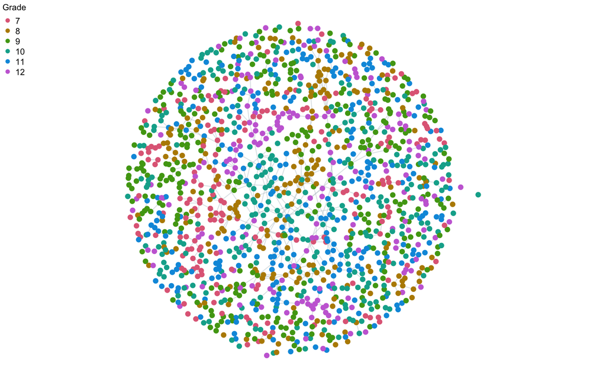

## Some Distributional Characteristics of Persons in the Network

```r
table(fmh %v% "Grade")
table(fmh %v% "Sex")
```

```
  7   8   9  10  11  12
185 210 317 299 257 193
```

```
  F   M
768 693
```

## Structure: who connects with whom?

```r
mixingmatrix(fmh, "Sex")
```

```
    F   M
F 430 285
M 285 259
```

- Most ties are in the diagonal cells.
- Indicates that friendships appear to cluster **within** sex (i.e., “homophily”).

## Structure: how many friends?

```r
summary(fmh ~ degree(0:5))
```

```
degree0 degree1 degree2 degree3 degree4 degree5
    524     403     271     128      85      30
```

- Most students have **few** ties
- A few students have many.
- The degree distribution is right-tailed.

## These summaries *are* network statistics

```r
summary(fmh ~ edges +
          nodematch("Grade") +
          nodematch("Race") +
          nodematch("Sex"))
```

```
          edges nodematch.Grade  nodematch.Race   nodematch.Sex
            974             820             787             689
```

Each cell represents a feature of the observed network.

## What is a “network target”?

- A target is a summary statistic we want the model to reproduce.
- Which targets to use is a question similar to considering model selection in regression.
- Includes parameters that “sufficiently” explain the process we are trying to model.

Code: - `summary(net ~ terms)` **computes** them from data - `ergm(net ~ terms, target.stats = …)` **fits a model to those numbers** - So we can model a network with **only aggregate summaries**, no full who-knows-whom matrix

## What is an ERGM?

**Similar to logistic regression for ties.**

- **Outcome:** does a tie exist between two people? (0/1)
- **Predictors:** network statistics (the target terms)
- **Coefficients:** log-odds of a tie, converted to probabilities

## Null model: ties form at random

```r
random.m <- ergm(fmh ~ edges)
plogis(coef(random.m))   # baseline tie probability
```

```
       edges
0.0009132421
```

Interpretation

- The `edges` coefficient is a **log-odds**.
- We convert it to a probability using `plogis()`, representing the “baseline” chance any two students are friends.
- The `edges` term models this baseline probability, akin to the **intercept** in regression modeling.

## Assortative mixing

```r
assort.m <- ergm(fmh ~ edges +
                   nodematch("Grade") +
                   nodematch("Race") +
                   nodematch("Sex"))
round(coef(assort.m), 2)
```

```
          edges nodematch.Grade  nodematch.Race   nodematch.Sex
         -10.01            3.23            1.20            0.88
```

- These `nodematch` terms allow us to estimate the probability that persons within the same grade, or of the same sex or race, are more likely to be friends.
- This is a **dyad-independent** model, a tie’s odds depend only on the two nodes’ attributes.
- Such models can be fit using standard logistic regression, and fit fast.
- Positive coefficients → ties are more likely **within** that attribute (homophily).

## Interpretation

- Baseline log-odds ≈ −10.0 → probability 4.5 × 10⁻⁵
- Same grade: −10.0 + 3.2 ≈ −6.8 → probability ≈ 0.001

## Is a better-fitting model *good enough*?

- “Better” is measured here in terms of **log-likelihood**.
- Higher **log-likelihood** means the observed ties are **more probable** under the model.
- But does the better fitting model *reproduce* the network structure we care about?
- The test: simulate many networks, compare to the target network statistics.

## Goodness of fit: null model

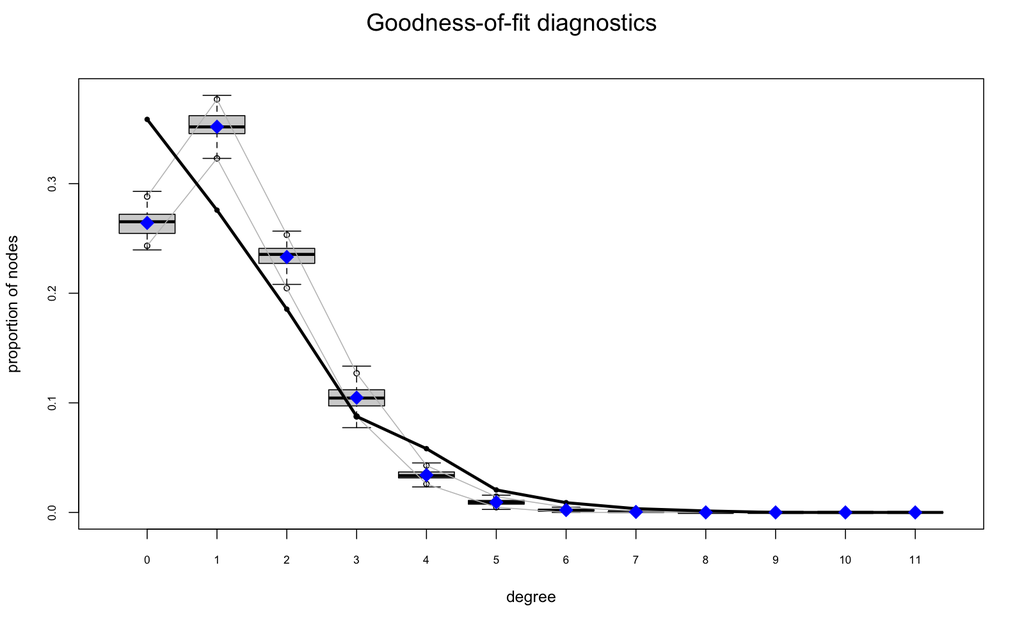

## Goodness of fit: assortative model

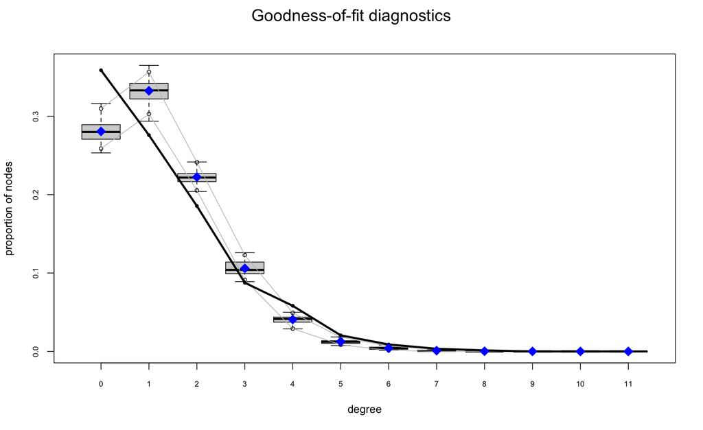

## Goodness of Fit

Observation

- While the alternative assortative mixing model fit better, neither adequately captured the network.

Why might that be?

- Our alternative model might still be missing something

Likely Candidate:

- In social networks, individuals who have common friends, are more likely to be friends with each other.
- Let us specify this property within our generative model.

## Fit the friend-of-a-friend model

Mechanism of interest: Triad Closure

- Two people with a shared friend are likely to connect.

Intuitive statistic to model this: Triangles

- Estimates the increased likelihood of a tie forming between two nodes with a shared friend (triadic closure).

But this does not account for the non-linearity in triad formation:

- The probability of connecting two people increases as the number of their shared friends increases.
- But this scaling is not linear.
- The probability of two people connecting is far greater if they know 2 vs. 4 people in common, than whether they know 100 vs. 102 people in common.
- So each additional shared friend should add **less** to the tie’s log-odds than the one before (i.e., **diminishing returns**).
- A `triangle` parameter instead adds a *constant* amount per shared partner (linear, unbounded), which drives **model degeneracy** (discussed later).
- Hence we specify a parameter with these diminishing returns.

## The GWESP model

**GWESP** (geometrically-weighted edgewise shared partners) model closure while down-weighting each *additional* shared friend .

```r
gwesp.m <- ergm(fmh ~ edges +
                  nodematch("Grade") +
                  nodematch("Race") +
                  nodematch("Sex") +
                  gwesp(0.25, fixed = TRUE))
round(coef(gwesp.m), 2)
```

```
           edges  nodematch.Grade   nodematch.Race    nodematch.Sex
           -9.78             2.74             0.91             0.77
gwesp.fixed.0.25
            1.80
```

- Dyad-dependent, i.e., the probability of two nodes being connected is dependent on other ties in the network.
- This one is fit by **MCMC**, unlike the models above, which used MLE.

## Goodness of fit: friend-of-a-friend model

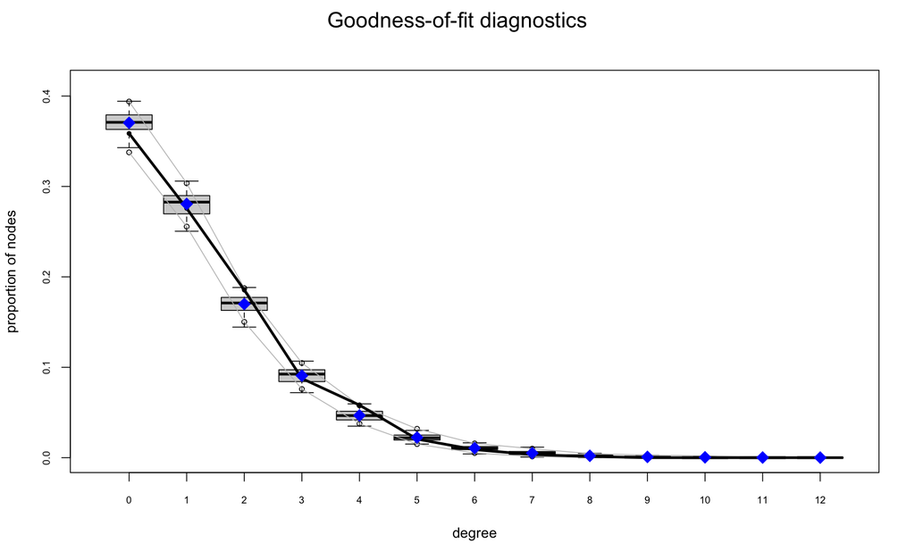

Much better

## Network targets, revisited

Target statistics are the bridge from data to model.

- Every summary statistic in this module (mixing, degree) is a candidate **target**
- `target.stats` specifies those statistics in a single vector
- GOF Testing checks whether the model reproduces them
- **Future modules:** targets come from aggregate data, no full network needed

## Simulate from the fitted model

A single network drawn from the assortative fit, beside the observed network:

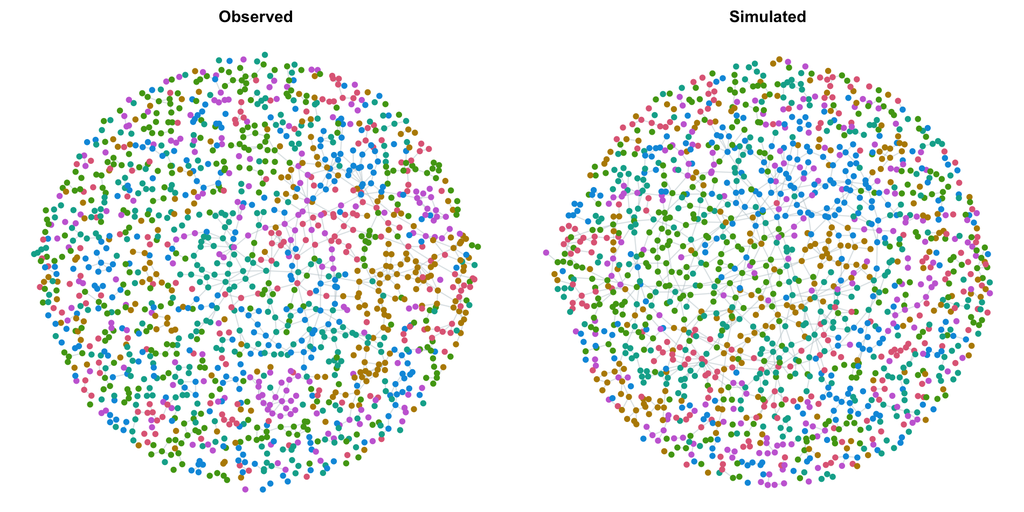

- A simulated network is a **draw from the model** (not a copy of the data).
- It reproduces what the model includes (i.e., assortative mixing).

## Most Importantly

- Using numerical methods to compare model fits is useful.
- But even a better fitting model is not always adequate.
- Proposing alternate models that capture relevant theoretical mechanisms is important.
- In practice, this process is often iterative and allows us to refine our understanding at each step.

## Funding acknowledgement

Research reported in this presentation was supported by the National Institute of Allergy and Infectious Diseases of the National Institutes of Health under award number R01AI158666. This project is financed 100% with federal funds: the FY2026 total for the prime award to Loyola University Chicago is $684,751, and Brown University’s subaward for the current budget period is $14,846. No portion is financed by non-governmental sources (0%, $0).

The content is solely the responsibility of the authors and does not necessarily represent the official views of the National Institutes of Health.

← All slides